# İsim: Muhammet Fatih

# Yapay Sinir Ağları Modelin Kurulması

```python
ysa_modeli = MLPRegressor().fit(X_egitim_scale, y_egitim)
print(" LAYERS: ",ysa_modeli.n_layers_,"\n", "LAYER SIZES: ",ysa_modeli.hidden_layer_sizes)
```

```
 LAYERS:  3
 LAYER SIZES:  (100,)
```

# Eğitim Verisi Üzerinden Tahmin (In-Sample Prediction)

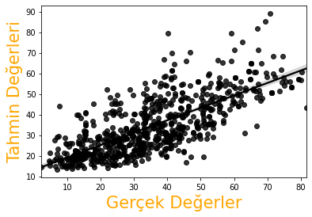

```python
y_hat_ysa=ysa_modeli.predict(X_egitim_scale)

fig, ax = mpl.subplots()
sb.regplot(y_egitim, y_hat_ysa, color="black")
ax.set_ylabel("Tahmin Değerleri", fontsize=21, color="orange")
ax.set_xlabel("Gerçek Değerler", fontsize=21, color="orange")
```

```python
print(" R2 Değeri:", r2_score(y_egitim,y_hat_ysa),"\n","MSE Değeri:",mean_squared_error(y_egitim,y_hat_ysa))
```

```
 R2 Değeri: 0.5261111156277252
 MSE Değeri: 135.41630667741794
```

### Grafik incelendiğinde, değerlerin birbirinden uzak olduğu görülüyor. Grafik üzerinden, iyi tahminlerin elde edilmediği görülüyor.

### R2 değerine göre, bağımlı değişkendeki toplam değişimin %52'si bağımsız değişkenler tarafından açıklanabilmiştir. Bu çok düşük bir değer.

### MSE değerine göre, tahmin edilen değerler gerçek değerlerden uzaktır.

### Modelin performansı yeterli değildir.

# Model Optimizasyonu

```python
np.random.seed(123)
parametreler = {"alpha" : [0.2,0.1,0.05,0.02,0.01,0.005],
                "hidden_layer_sizes": [(20,50,100),(100,85,40),(50,120,20),(140,70,220,160)],"activation": ["relu","logistic"]}

gs_ysa_model = GridSearchCV(ysa_modeli, parametreler, cv=5)
gs_ysa_model.fit(X_egitim_scale, y_egitim)
gs_ysa_model.best_params_
```

```
{'activation': 'relu',
 'alpha': 0.05,
 'hidden_layer_sizes': (140, 70, 220, 160)}
```

### En iyi parametreler: activation için 'relu', alpha için '0.05', hidden_layer_sizes için (140, 70, 220,160) olarak belirlendi. Bu parametrelerle model kurulup modelin performansına bakılmalıdır.

# En İyi Parametrelerle Yapay Sinir Ağları Modelin Kurulması

```python
best_ysa_model= MLPRegressor(alpha=0.05, hidden_layer_sizes=(140,70,220,160), activation="relu").fit(X_egitim_scale,y_egitim)
```

# Eğitim Verisi Üzerinden Tahmin (In-Sample Prediction)

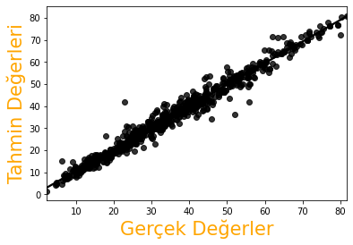

```python
best_tahmin_ysa=best_ysa_model.predict(X_egitim_scale)

fig, ax = mpl.subplots()
sb.regplot(y_egitim, best_tahmin_ysa, color="black")
ax.set_ylabel("Tahmin Değerleri", fontsize=21, color="orange")
ax.set_xlabel("Gerçek Değerler", fontsize=21, color="orange")
```

```python
print(" R2 Değeri:",r2_score(y_egitim, best_tahmin_ysa),"\n","MSE Değeri:",mean_squared_error(y_egitim, best_tahmin_ysa))
```

```
 R2 Değeri: 0.9742103715910104
 MSE Değeri: 7.36952552570297
```

### Modelin performansı çok iyidir.

# Test Verisi Üzerinden Tahmin (Out-Of-Sample Prediction)

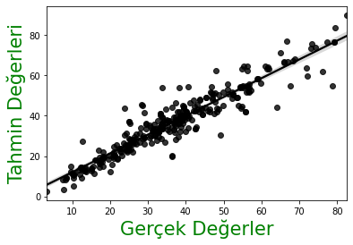

```python
best_tahmin_test_ysa=best_ysa_model.predict(X_test_scale)

fig, ax = mpl.subplots()
sb.regplot(y_test, best_tahmin_test_ysa, color="black")
ax.set_ylabel("Tahmin Değerleri", fontsize=21, color="green")
ax.set_xlabel("Gerçek Değerler", fontsize=21, color="green")
```

```python
print(" R2 Değeri:",r2_score(y_test, best_tahmin_test_ysa),"\n","MSE Değeri:",mean_squared_error(y_test, best_tahmin_test_ysa))
```

```
 R2 Değeri: 0.8827999400892648
 MSE Değeri: 30.718979427407383
```

### MSE değerine göre, tahmin edilen değerler gerçek değerlere çok yakındır.

### Grafik incelendiğinde, değerlerin çoğunun doğru üzerinde yoğunlaştığı görülüyor. Bu durum, modelin test verisi üzerinden de iyi tahmin yaptığını gösteriyor.

### Modelin performansı yeterli seviyededir.

# Karar Ağaçları (Classification and Regression Trees (CART))

# Modelin Kurulması

```python
cart_model0 = DecisionTreeRegressor().fit(X_egitim, y_egitim)
```